# Mantodea en Uruguay

Observaciones en NaturalistaUY

Authors

Florencia Grattarola

Marianela Larramendy

Gabriela Rivero

Sabrina Romero

Mariana Trillo

Published

April 30, 2026

## Librerías de R

Este código que sigue, es donde leemos las librerías o paquetes de R.

```r
library(patchwork)
library(janitor)
library(httr)
library(jsonlite)
library(lubridate)
library(tmap)
tmap_mode('view')
library(sf)
sf_use_s2(FALSE)
library(tidyverse)
```

## Datos

### Descarga de iNaturalist

Para la descarga vamos a usar funciones hechas para descargar datos mediante la API de iNaturalist (https://api.inaturalist.org/v1/docs/). Esta parte también se podría hacer a través de la plataforma, pero de esta manera podemos automatizar la descarga y obtener directamente los campos que nos interesan.

Las funciones que vamos a usar van a estar en la carpeta code/funciones del repositorio de GitHub. Pueden ver acá ejemplos de reportes hechos usando estas funciones: https://bienflorencia.github.io/LatinR2024/.

```r
source("codigo/funciones.R")
```

```r
id_proyecto <- 'mantodea-de-uruguay'

# todos los registros de mantodea
datos_mantodea <- getProjectData(id_proyecto)

# los registros de mantodea de adultos y ninfas
datos_mantodea_adultos_y_ninfas <- getProjectDataWithAnnotation(id_proyecto,
                                                                annotation_id = 1,
                                                                annotation_value = c(2,5))

# guardo los datos como en formato RDS
saveRDS(datos_mantodea, 'datos/datos_mantodea.rds')
saveRDS(datos_mantodea_adultos_y_ninfas, 'datos/datos_mantodea_adultos_y_ninfas.rds')
```

### Exploración

Vamos a chequear una serie de campos y filtrar los datos de acuerdo a nuestras preferencias. Por ejemplo, sobre los campos: `captive`, `observed_on`, `taxon_rank`, `research_quality`, y `geoprivacy`, entre otros.

```r
# exploro los datos (dos formas de hacer lo mismo)
# view(datos_mantodea_adultos_y_ninfas)
# datos_mantodea_adultos_y_ninfas %>% view()

# selecciono columnas
datos_mantodea_adultos_y_ninfas %>%
  select(taxon_name, user_login) %>% # me quedo con dos columnas
  head(n=10) # me quedo con las 10 primeras filas

# filtro filas según valores de ciertas columnas
datos_mantodea_adultos_y_ninfas %>%
  filter(taxon_name == 'Coptopteryx gayi') %>%
  head(n=10)

# ¿cuántos registros de Coptopteryx gayi hay?
datos_mantodea_adultos_y_ninfas %>%
  filter(taxon_name == 'Coptopteryx gayi') %>% # filtro los que tienen Coptopteryx gayi como taxon_name
  count() # cuento la cantidad de registros

# ¿cuántos registros de cada especie hay?
datos_mantodea_adultos_y_ninfas %>%
  filter(taxon_rank == 'species') %>% # primero filtro sólo las especies
  group_by(taxon_name) %>% # agrupo por el nombre de la especie
  count() # cuento la cantidad de registros por especie

# ¿qué taxones tienen menos de 5 registros en toda la plataforma?
datos_mantodea_adultos_y_ninfas %>%
  filter(observations_count < 5) %>%
  select(taxon_name, observations_count, user_login) # selecciono solo algunos campos

# ¿cuántos registros tienen grado de investigación y cuántos necesitan ID?
datos_mantodea_adultos_y_ninfas %>%
  group_by(quality_grade) %>%
  count()

# ¿cuántos registros hay para cada nivel taxonómico?
datos_mantodea_adultos_y_ninfas %>%
  group_by(taxon_rank) %>%
  count()

# ¿cuántos registros de individuos "cautivos o cultivados" hay?
datos_mantodea_adultos_y_ninfas %>%
  group_by(captive) %>%
  count()
```

Estos son los registros que están a nivel de especie pero todavía necesitan identificación. Sería bueno revisarlos.

```r
# para revisar
datos_mantodea %>%
    filter(quality_grade == 'needs_id') %>%
    filter(taxon_rank == 'species')
```

### Limpieza final

Finalmente, limpio los datos y los guardo.

```r
# hago el filtrado final y lo guardo en un nuevo objeto
datos_mantodea_adultos_y_ninfas_limpios <- datos_mantodea_adultos_y_ninfas %>%
  filter(taxon_rank == 'species') %>%
  filter(quality_grade == 'research') %>%
  filter(is.na(geoprivacy)) %>% # esto es igual a hacer: filter(geoprivacy != 'obscured')
  select(observation_id, taxon_name, observed_on, user_login,
         latitude, longitude, state_name)

# estandarización de especies sinónimas
datos_mantodea_adultos_y_ninfas_limpios <- datos_mantodea_adultos_y_ninfas_limpios %>%
  mutate(taxon_name = ifelse(taxon_name == 'Metaphotina brevipennis', 'Metaphotina bimaculata', taxon_name))


# guardo los datos
saveRDS(datos_mantodea_adultos_y_ninfas_limpios, 'datos/datos_mantodea_adultos_y_ninfas_limpios.rds')
```

### Datos espaciales

Para poder mapear los datos vamos a precisar un mapa de Uruguay. Vamos a descargarlo usando el paquete [`geouy`](https://richdeto.github.io/geouy/).

```r
departamentos <- geouy::load_geouy('Departamentos', folder = 'datos/')
uruguay <- nngeo::st_remove_holes(st_union(departamentos))
```

## Mapeo de observaciones

### Creación de objeto espacial

Para generar un mapa de distribución por especie, primero tenemos que pasar los datos de texto (`data.frame` o `tibble`) a formato espacial, usando el paquete `sf`.

```r
datos_mantodea_sf <- datos_mantodea_adultos_y_ninfas_limpios %>%
  st_as_sf(coords = c("longitude", "latitude")) %>%
  st_set_crs(4326) %>% # primero indico el sistema de coordenadas de los datos
  st_transform(32721) # después proyecto las coordenadas a UTM 21 S
```

### Mapas

Ahora que tenemos los datos en formato espacial, podemos probar con mapear los puntos. Los mapas los podemos crear usando los paquetes `ggplot` o `tmap` (que es específico para mapas).

- `ggplot`

Mapa sencillo

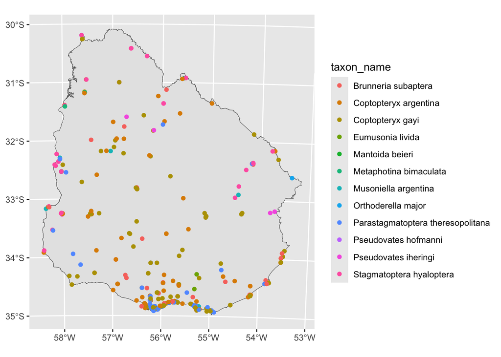

```r
ggplot() +
  geom_sf(data = uruguay) +
  geom_sf(data = datos_mantodea_sf,
          aes(col = taxon_name))
```

Un mapa con más detalles

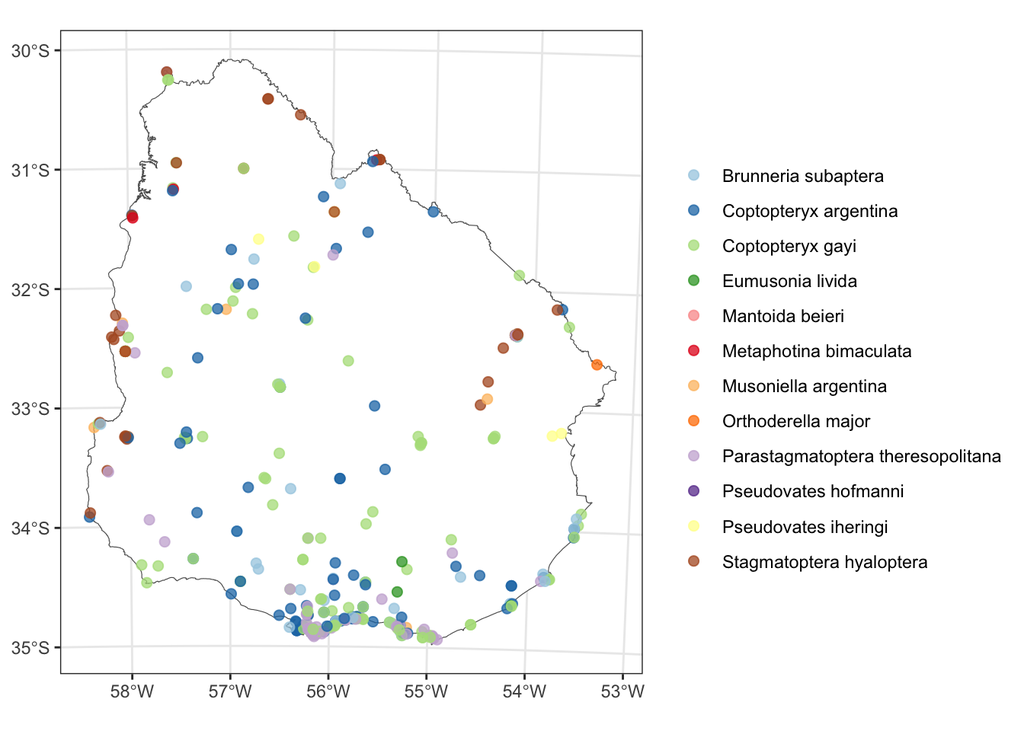

```r
ggplot() +
  geom_sf(data = uruguay, fill='white') +
  geom_sf(data = datos_mantodea_sf,
          aes(col = taxon_name), alpha = 0.75, size = 2) +
  scale_color_brewer(palette = 'Paired') +
  labs(col = '') +
  theme_bw()
```

- `tmap`

Podemos crear una versión estática del mapa o una versión dinámica.

```r
tmap_mode('view')
tm_shape(datos_mantodea_sf) +
  tm_dots('taxon_name',
          size = 0.5, fill_alpha = .75,
          fill.scale = tm_scale(values = 'brewer.paired'),
          fill.legend = tm_legend(title = '',
                                  frame=F)) +
  tm_layout(legend.outside = T,  frame=F)
```

[interactive chart not shown]

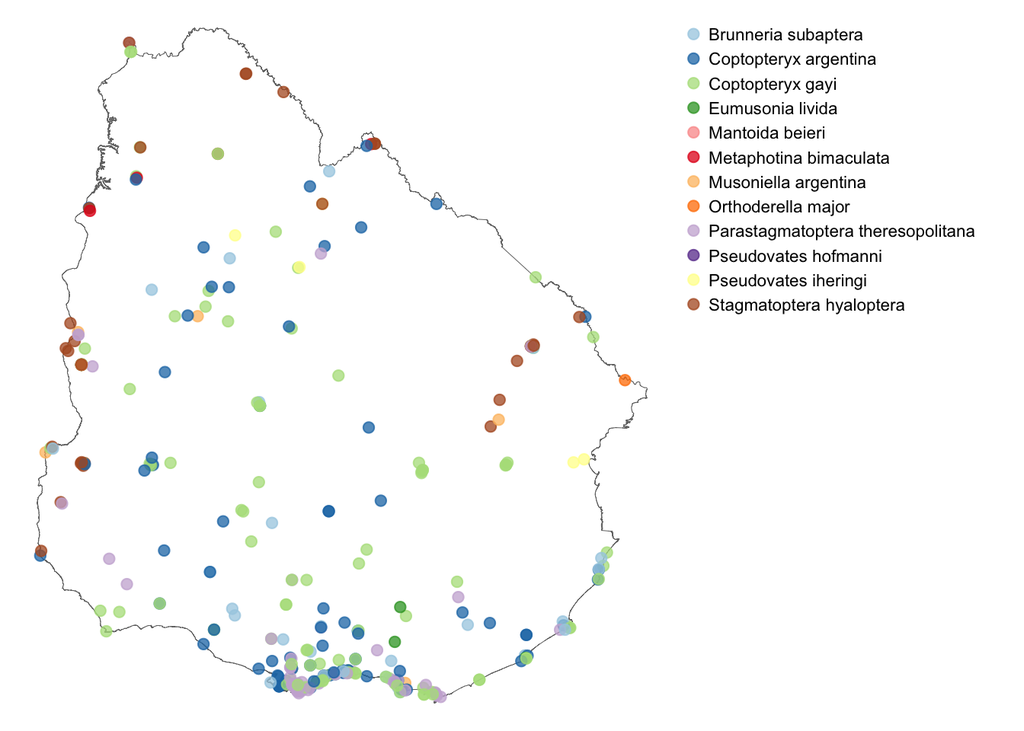

```r
tmap_mode('plot')

tm_shape(uruguay) +
  tm_borders(col = 'grey45', lwd=0.5) +
tm_shape(datos_mantodea_sf) +
  tm_dots('taxon_name',
          size = 0.5, fill_alpha = .75,
          fill.scale = tm_scale(values = 'brewer.paired'),
          fill.legend = tm_legend(title = '',
                                  frame=F)) +
  tm_layout(legend.outside = T,  frame=F)
```

## Otros análisis espaciales posibles

### Densidad por departamento

Para esto vamos a hacer un *join* espacial y contar la cantidad de registros, especies y usuarios registrando por departamento.

```r
registros_por_departamento <- st_join(departamentos, datos_mantodea_sf) %>%
  group_by(gid) %>%
  summarise(n_registros = n(),
            n_especies = n_distinct(taxon_name),
            n_usuarios = n_distinct(user_login))
```

#### Mapas

Ahora podemos mapear los valores: registros, especies, y usuarios.

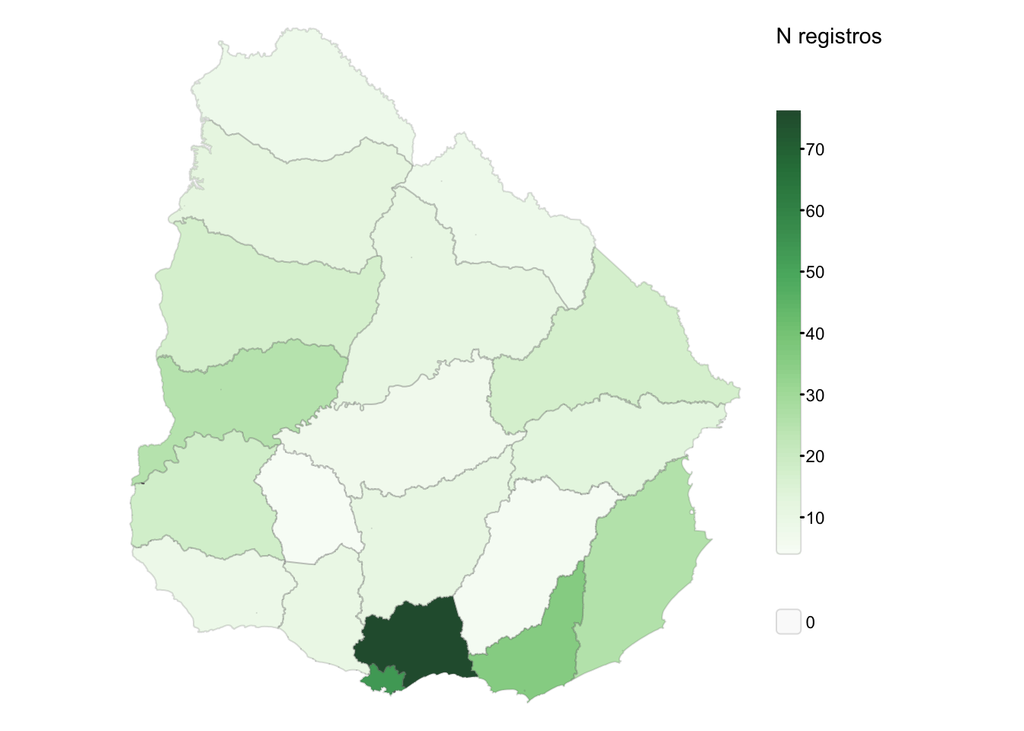

```r
tm_shape(registros_por_departamento) +
    tm_polygons(
        fill = "n_registros",
        fill.scale = tm_scale_continuous(
            n = 7,
            values = "brewer.greens",
            value.na = "grey90",
            label.na = "0"
        ),
        fill_alpha = 0.9,
        fill.legend = tm_legend(
            title = "N registros",
            item.space = 0,
            item.na.space = 0,
            reverse = TRUE,
            frame = F
        ),
        col = "grey40",
        col_alpha = 0.2
    ) +
    tm_layout(
        #legend.position = c("left", "bottom"),
        legend.outside = TRUE,
        frame = F
    ) + tm_options(component.autoscale = FALSE)
```

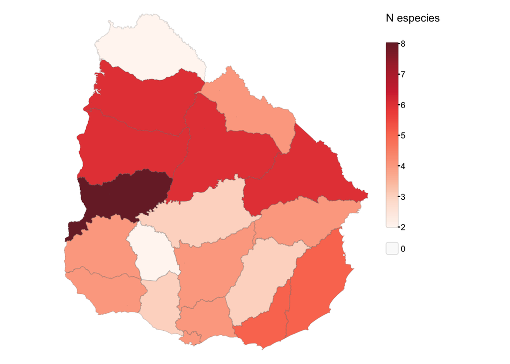

```r
tm_shape(registros_por_departamento) +
    tm_polygons(
        fill = "n_especies",
        fill.scale = tm_scale_continuous(
            n = 5,
            values = "brewer.reds",
            value.na = "grey90",
            label.na = "0"
        ),
        fill_alpha = 0.9,
        fill.legend = tm_legend(
            title = "N especies",
            item.space = 0,
            item.na.space = 0,
            reverse = TRUE,
            frame = F
        ),
        col = "grey40",
        col_alpha = 0.2
    ) +
    tm_layout(
        #legend.position = c("left", "bottom"),
        legend.outside = TRUE,
        frame = F
    ) + tm_options(component.autoscale = FALSE)
```

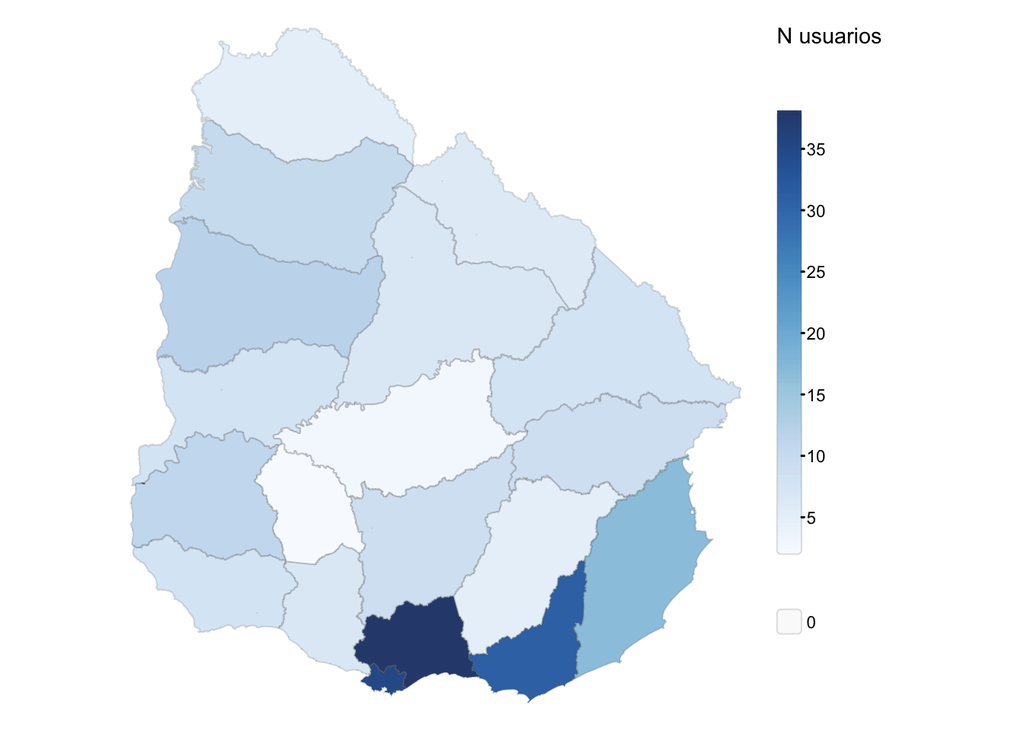

```r
tm_shape(registros_por_departamento) +
    tm_polygons(
        fill = "n_usuarios",
        fill.scale = tm_scale_continuous(
            n = 7,
            values = "brewer.blues",
            value.na = "grey90",
            label.na = "0"
        ),
        fill_alpha = 0.9,
        fill.legend = tm_legend(
            title = "N usuarios",
            item.space = 0,
            item.na.space = 0,
            reverse = TRUE,
            frame = F
        ),
        col = "grey40",
        col_alpha = 0.2
    ) +
    tm_layout(
        #legend.position = c("left", "bottom"),
        legend.outside = TRUE,
        frame = F
    ) + tm_options(component.autoscale = FALSE)
```

### Densidad por grilla

Para esto, vamos a tener que crear una grilla para Uruguay que tenga un tamaño de 25x25km (por ejemplo, que son 25,000 metros).

```r
grillas_uruguay <- st_make_grid(uruguay,
                                cellsize = 25000,
                                square = F) %>%
  st_intersection(uruguay) %>%
  st_sf(gridID=1:length(.)) # necesario para el join!
```

Ahora hacemos un *join* espacial, haciendo uso de la identidad de la grilla (`gridID`) y contando la cantidad de registros, especies y usuarios por grilla.

```r
registros_por_grilla <- st_join(grillas_uruguay, datos_mantodea_sf) %>%
  group_by(gridID) %>%
  summarise(n_registros = ifelse(n_distinct(taxon_name, na.rm=T)!=0, n(), 0),
            n_especies = n_distinct(taxon_name, na.rm=T),
            n_usuarios = n_distinct(user_login, na.rm=T))
```

#### Mapas

Ahora podemos mapear los valores: registros, especies, y usuarios.

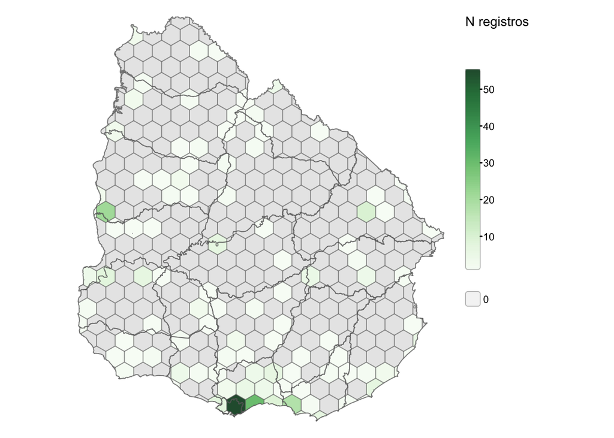

```r
registros_por_grilla %>%
  mutate(n_registros = ifelse(n_registros ==0, NA, n_registros)) %>%
  tm_shape() +
    tm_polygons(
        fill = "n_registros",
        fill.scale = tm_scale_continuous(
            n = 5,
            values = "brewer.greens",
            value.na = "grey90",
            label.na = "0"
        ),
        fill_alpha = 0.9,
        fill.legend = tm_legend(
            title = "N registros",
            item.space = 0,
            item.na.space = 0,
            reverse = TRUE,
            frame = F
        ),
        col = "grey40",
        col_alpha = 0.4
    ) +
  tm_shape(departamentos) +
  tm_borders(col = "grey40",
             col_alpha = 0.6) +
    tm_layout(
        #legend.position = c("left", "bottom"),
        legend.outside = TRUE,
        frame = F
    ) + tm_options(component.autoscale = FALSE)
```

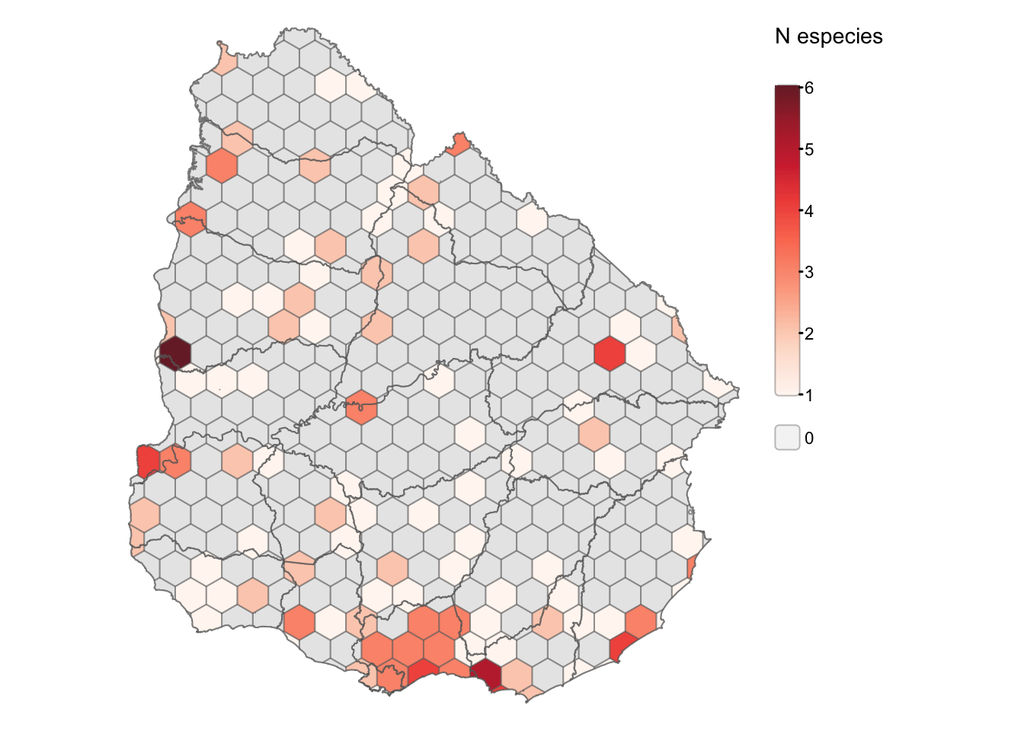

```r
registros_por_grilla %>%
  mutate(n_especies = ifelse(n_especies ==0, NA, n_especies)) %>%
  tm_shape() +
    tm_polygons(
        fill = "n_especies",
        fill.scale = tm_scale_continuous(
            n = 5,
            values = "brewer.reds",
            value.na = "grey90",
            label.na = "0"
        ),
        fill_alpha = 0.9,
        fill.legend = tm_legend(
            title = "N especies",
            item.space = 0,
            item.na.space = 0,
            reverse = TRUE,
            frame = F
        ),
        col = "grey40",
        col_alpha = 0.4
    ) +
  tm_shape(departamentos) +
  tm_borders(col = "grey40",
             col_alpha = 0.6) +
    tm_layout(
        #legend.position = c("left", "bottom"),
        legend.outside = TRUE,
        frame = F
    ) + tm_options(component.autoscale = FALSE)
```

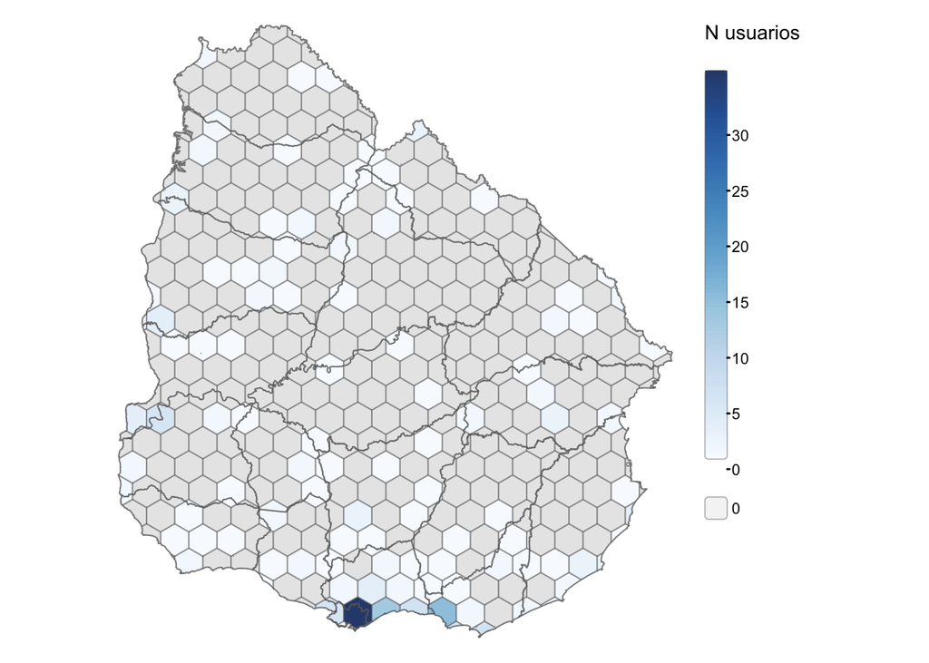

```r
registros_por_grilla %>%
  mutate(n_usuarios = ifelse(n_usuarios ==0, NA, n_usuarios)) %>%
  tm_shape() +
    tm_polygons(
        fill = "n_usuarios",
        fill.scale = tm_scale_continuous(
            n = 5,
            values = "brewer.blues",
            value.na = "grey90",
            label.na = "0"
        ),
        fill_alpha = 0.9,
        fill.legend = tm_legend(
            title = "N usuarios",
            item.space = 0,
            item.na.space = 0,
            reverse = TRUE,
            frame = F
        ),
        col = "grey40",
        col_alpha = 0.4
    ) +
  tm_shape(departamentos) +
  tm_borders(col = "grey40",
             col_alpha = 0.6) +
    tm_layout(
        #legend.position = c("left", "bottom"),
        legend.outside = TRUE,
        frame = F
    ) + tm_options(component.autoscale = FALSE)
```

## Datos de la literatura

*Correr esta parte siguiendo los pasos anteriores*

### Leer los datos

```r
# datos_literatura <- read_csv('datos/xxxxxxxxxxx.csv')
# datos_literatura <- readxl::read_excel('datos/xxxxxxxxxxx.xlsx')
```

### Transformar los datos en un objeto espacial

```r
# tener en cuenta qué campos representan latitud y longitud
```

### Mapas

```r
# por departamento (uruguay)
# por grilla (grillas_uruguay)
```